# Reproducible Research: Peer Assessment 1

1. First, we load the data and transform **date** and **interval** into factor variables.

```r
activity <- read.csv("~/Downloads/activity.csv", header = T)
activity = transform(activity, date = factor(date),
                     interval = factor(interval))
```

2. Ignoring the missing values, we got the histogram of total number of steps taken per day as below.

```r
library(dplyr)
```

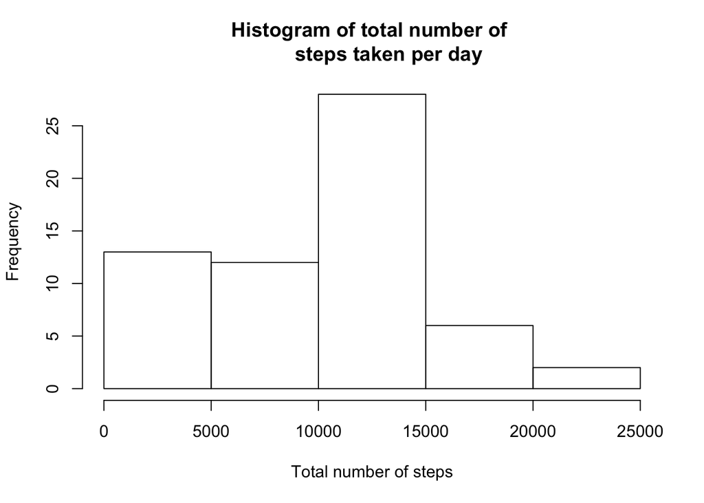

```r
library(lattice)
steps_mean1 <-
  activity %>%
    group_by(date) %>%
      summarize(day_steps = sum(steps, na.rm = T))
hist(steps_mean1$day_steps, main = "Histogram of total number of
      steps taken per day", xlab = "Total number of steps")
```

```r
mean1 <- mean(steps_mean1$day_steps)
median1 <- median(steps_mean1$day_steps)
```

The mean and median of the total number of steps taken per day is 9354.2295082 and 10395, respectively.

3. The time series plot of the 5-minute interval and the average number of steps taken averaged across all days is as below.

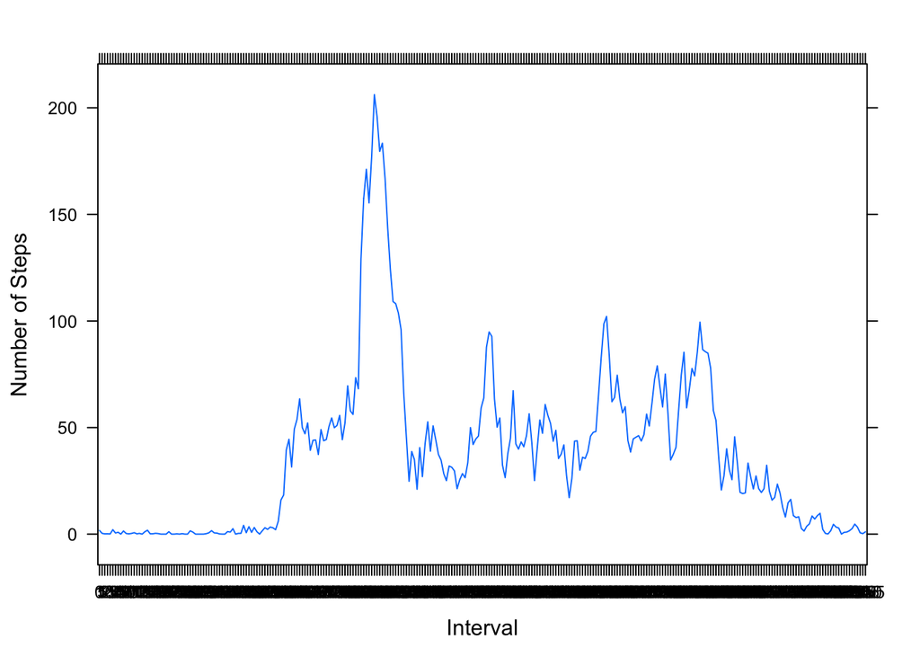

```r
steps_mean2 <-
  activity %>%
    group_by(interval) %>%
      summarize(int_steps = mean(steps, na.rm = T))
xyplot(int_steps ~ interval, data = steps_mean2, type = 'l',
       xlab = "Interval", ylab = "Number of Steps")
```

```r
max <-
  steps_mean2 %>%
    filter(int_steps == max(int_steps))
```

The 5-minuter interval with the maximum number of steps in 835, 206.1698113, which the former value is the interval id and the later value is the maximum number of steps.

```r
activity %>%
  group_by(date)
```

[output not shown]

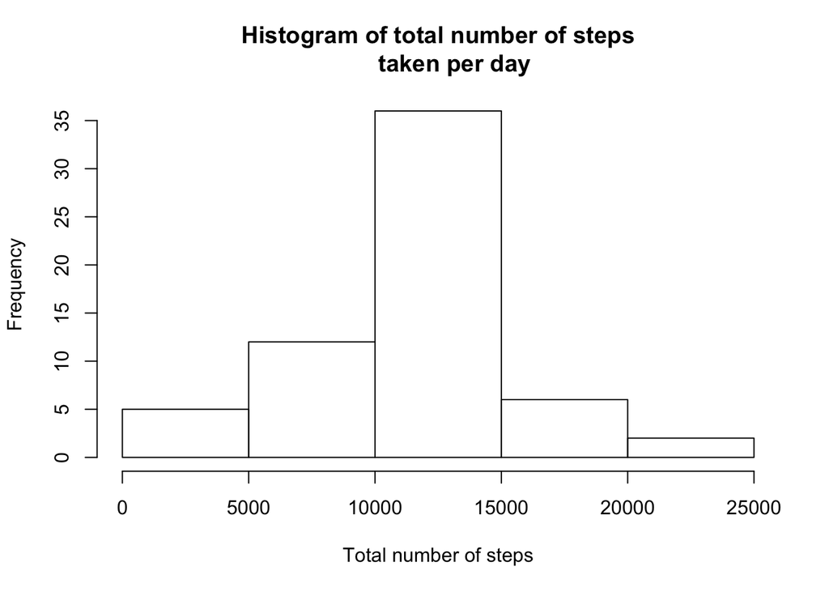

```r
activity2 <-  mutate(activity, steps = ifelse(is.na(steps),
                            as.integer(mean(steps, na.rm = T)),
                            steps))
steps_mean3 <-
  activity2 %>%
    group_by(date) %>%
      summarize(day_steps = sum(steps))
hist(steps_mean3$day_steps, main = "Histogram of total number of steps
     taken per day", xlab = "Total number of steps")
```

```r
mean2 <- mean(steps_mean3$day_steps)
median2 <- median(steps_mean3$day_steps)
```

5. *days_ends* is the new factor variable with the two levels: “weekday” and “weekend”. Below is the panel plot.

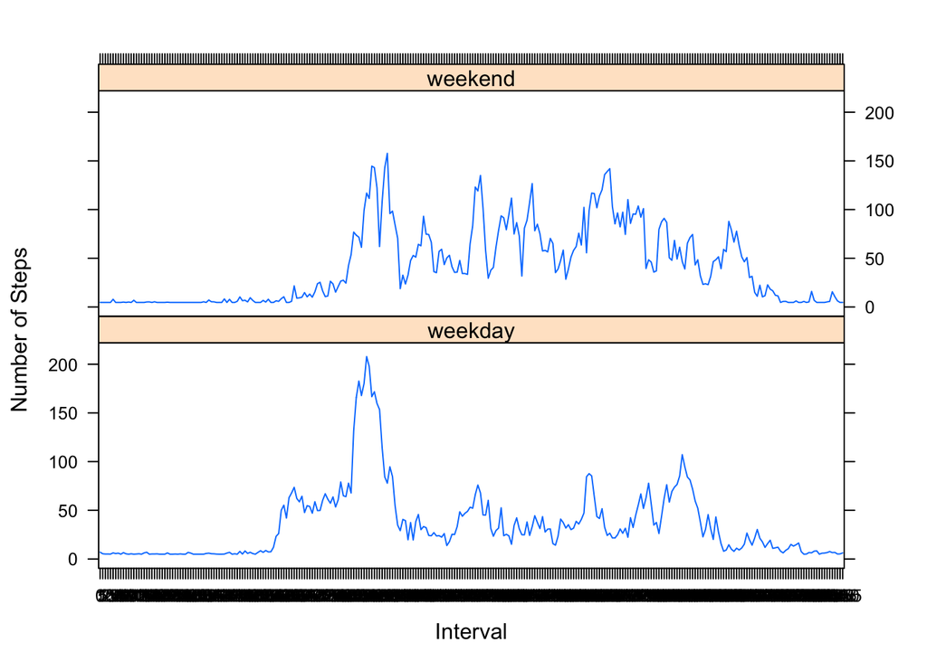

```r
steps_mean4 <-
  activity2 %>%
    mutate(days_ends = weekdays(as.Date(date))) %>%
      mutate(days_ends = ifelse((days_ends == "Saturday" |
                                   days_ends == "Sunday"),
                                  "weekend","weekday")) %>%
        group_by(interval, days_ends) %>%
          summarize(int_steps = mean(steps, na.rm = T))
xyplot(int_steps ~ interval | days_ends, data = steps_mean4, type = 'l',
       layout = c(1,2), xlab = "Interval", ylab = "Number of Steps")
```